# Curso II – SISSA

Ejercicio 4

## Bienvenida/o

Bienvenida/o al cuarto ejercicio práctico del *Taller de fusión de datos satelitales con estaciones*. ¡Esperamos que esté listo para probar algunas cosas!

## Esquema

Este tutorial está compuesto por dos ejercicios:

- Evaluación del desempeño mensual de productos de precipitación.
- Análisis de la distribución espacial de estaciones según el porcentaje de datos faltantes.

Después de completar este tutorial, podrás evaluar el desempeño de productos de precipitación teniendo en cuenta la distribución espacial de los datos disponibles.

### Objetivo de la tarea

Para este ejercicio, los estudiantes deberán:

1. Evaluación del desempeño mensual de productos de precipitación basándose en los pasos realizados en el Módulo 7.
2. Evaluar la distribución espacial de las estaciones resultantes al seleccionar estaciones con menos del 50%, 25%, 10% y 5% de datos faltantes.

### Solucion inciso A

**Paso 1**: Primero cargaremos las series temporales observadas y los metadatos. Para esto, almacenemos las rutas a los archivos:

```r
observations_path <- 'C:/Users/Data/timeseries_1850-2022.zoo'
metadata_path     <- 'C:/Users/Data/metadata.csv'
```

Después, utilizaremos la función **read.zoo** cargando el paquete **hydroGOF** para leer las series temporales, y la función **read.csv** para leer los metadatos.

```r
library(hydroGOF)
```

```r
observations <- read.zoo(observations_path, header = TRUE)
metadata     <- read.csv(metadata_path)
dim(observations)
```

```
## [1] 62511  1377
```

```r
dim(metadata)
```

```
## [1] 1377    6
```

```r
observations[1:5, 1:5]
```

```
##            BC000068026 BC000068032 BC000068226 BC000068328 BC004612080
## 1850-01-01          NA          NA          NA          NA          NA
## 1850-01-02          NA          NA          NA          NA          NA
## 1850-01-03          NA          NA          NA          NA          NA
## 1850-01-04          NA          NA          NA          NA          NA
## 1850-01-05          NA          NA          NA          NA          NA
```

```r
head(metadata)
```

```
##            ID LATITUDE LONGITUDE ELEMENT YEAR_START YEAR_END
## 1 BC000068026  -18.367    21.850    PRCP       1932     1992
## 2 BC000068032  -19.983    23.417    PRCP       1921     2022
## 3 BC000068226  -24.017    21.883    PRCP       1958     1992
## 4 BC000068328  -26.050    22.450    PRCP       1939     1992
## 5 BC004612080  -26.467    20.617    PRCP       1960     2022
## 6 BC005452830  -25.220    25.670    PRCP       1921     1989
```

Podemos ver que tenemos un total de 1377 estaciones. Pero las series temporales empiezan en 1850 y terminan en 2022.

```r
head(index(observations))
```

```
## [1] "1850-01-01" "1850-01-02" "1850-01-03" "1850-01-04" "1850-01-05"
## [6] "1850-01-06"
```

```r
tail(index(observations))
```

```
## [1] "2022-07-01" "2022-08-01" "2022-09-01" "2022-10-01" "2022-11-01"
## [6] "2022-12-01"
```

Hay que hacer un subset temporal a este objeto para conservar solo el periodo 1990-1992:

```r
observations <- hydroTSM::extract(observations, trgt = 1990:1992)
dim(observations)
```

```
## [1] 1096 1377
```

```r
head(index(observations))
```

```
## [1] "1990-01-01" "1990-01-02" "1990-01-03" "1990-01-04" "1990-01-05"
## [6] "1990-01-06"
```

```r
tail(index(observations))
```

```
## [1] "1992-12-26" "1992-12-27" "1992-12-28" "1992-12-29" "1992-12-30"
## [6] "1992-12-31"
```

**Paso 2**: Analizar el número de datos faltantes en cada estación. Para esto, vamos a crear una función básica:

```r
get_ratio_md <- function(x){

  md <- sum(is.na(x)) / length(x)
  return(md)

}
```

Ahora la aplicaremos a cada una de las series temporales (columnas del objeto *zoo*). Recuerda que el 2 significa que aplicaremos la función por columna.

```r
missing_data <- apply(observations, 2, get_ratio_md)
head(missing_data, 6)
```

```
##  BC000068026  BC000068032  BC000068226  BC000068328  BC004612080  BC005452830
## 0.0027372263 0.0000000000 0.0009124088 0.0018248175 0.0000000000 1.0000000000
```

Podemos generar un histograma para visualizar la distribución de los datos faltantes:

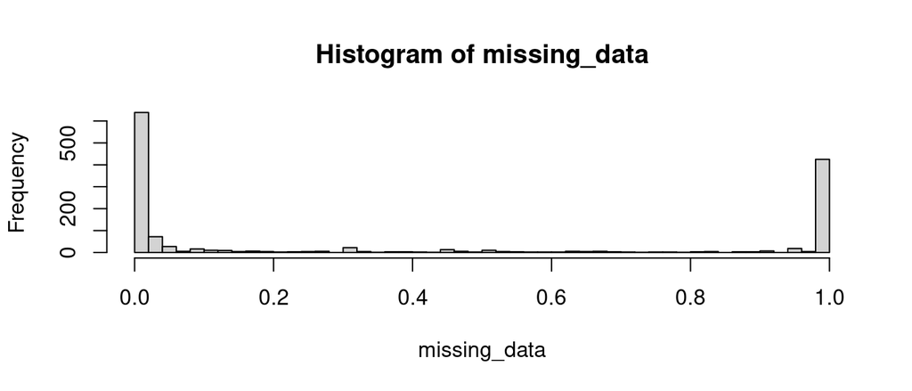

```r
hist(missing_data, breaks = 50)
```

Seleccionemos un umbral de 0.2 como límite de datos faltantes. Es decir, conservaremos las estaciones que tengan menos del 20% de datos faltantes.

```r
exclude_pos      <- which(missing_data > 0.20)
exclude_stations <- names(observations)[exclude_pos]
length(exclude_stations)
```

```
## [1] 585
```

```r
head(exclude_stations)
```

```
## [1] "BC005452830" "BC005836580" "BC006270240" "BC006282050" "BC007034890"
## [6] "BC007591160"
```

Ahora tenemos que remover dichas estaciones tanto de las series temporales como de los metadatos:

```r
observations <- observations[,-exclude_pos]
dim(observations)
```

```
## [1] 1096  792
```

```r
metadata_pos <- which(metadata$ID %in% exclude_stations)
metadata     <- metadata[-metadata_pos,]
dim(metadata)
```

```
## [1] 792   6
```

**Paso 3**: Una vez que tenemos las series temporales y los metadatos de las estaciones que utilizaremos, vamos a cargar los productos de precipitación. Para esto, guardemos las rutas de los productos en dos objetos:

```r
chirps_path <- 'C:/Users/Data/CHIRPSv2/'
mswep_path  <- 'C:/Users/Data//MSWEPv2.8/'
```

Ahora listemos los archivos que se encuentran en ambas carpetas.

```r
chirps <- list.files(chirps_path, full.names = TRUE)
mswep  <- list.files(mswep_path, full.names = TRUE)
head(chirps)
```

```
## [1] "../Data/Exercise_4/Daily_P_Data/CHIRPSv2//chirps_daily_19900101.tif"
## [2] "../Data/Exercise_4/Daily_P_Data/CHIRPSv2//chirps_daily_19900102.tif"
## [3] "../Data/Exercise_4/Daily_P_Data/CHIRPSv2//chirps_daily_19900103.tif"
## [4] "../Data/Exercise_4/Daily_P_Data/CHIRPSv2//chirps_daily_19900104.tif"
## [5] "../Data/Exercise_4/Daily_P_Data/CHIRPSv2//chirps_daily_19900105.tif"
## [6] "../Data/Exercise_4/Daily_P_Data/CHIRPSv2//chirps_daily_19900106.tif"
```

```r
head(mswep)
```

```
## [1] "../Data/Exercise_4/Daily_P_Data/MSWEPv2.8//MSWEPv280_1990-01-01.tif"
## [2] "../Data/Exercise_4/Daily_P_Data/MSWEPv2.8//MSWEPv280_1990-01-02.tif"
## [3] "../Data/Exercise_4/Daily_P_Data/MSWEPv2.8//MSWEPv280_1990-01-03.tif"
## [4] "../Data/Exercise_4/Daily_P_Data/MSWEPv2.8//MSWEPv280_1990-01-04.tif"
## [5] "../Data/Exercise_4/Daily_P_Data/MSWEPv2.8//MSWEPv280_1990-01-05.tif"
## [6] "../Data/Exercise_4/Daily_P_Data/MSWEPv2.8//MSWEPv280_1990-01-06.tif"
```

Finalmente, podemos utilizar la función **rast** del paquete **terra** para importar cada conjunto de archivos:

```r
chirps <- rast(chirps)
mswep <- rast(mswep)
print(chirps)
```

```
## class       : SpatRaster
## dimensions  : 78, 86, 1096  (nrow, ncol, nlyr)
## resolution  : 0.25, 0.25  (x, y)
## extent      : 11.625, 33.125, -34.875, -15.375  (xmin, xmax, ymin, ymax)
## coord. ref. : lon/lat WGS 84 (EPSG:4326)
## sources     : chirps_daily_19900101.tif
##               chirps_daily_19900102.tif
##               chirps_daily_19900103.tif
##               ... and 1093 more source(s)
## names       : chirp~00101, chirp~00102, chirp~00103, chirp~00104, chirp~00105, chirp~00106, ...
## min values  :     0.00000,     0.00000,     0.00000,     0.00000,     0.00000,      0.0000, ...
## max values  :    56.70765,    29.22468,    44.08159,    39.65398,    38.00595,     37.1624, ...
```

```r
print(mswep)
```

```
## class       : SpatRaster
## dimensions  : 78, 86, 1096  (nrow, ncol, nlyr)
## resolution  : 0.25, 0.25  (x, y)
## extent      : 11.625, 33.125, -34.875, -15.375  (xmin, xmax, ymin, ymax)
## coord. ref. : lon/lat WGS 84 (EPSG:4326)
## sources     : MSWEPv280_1990-01-01.tif
##               MSWEPv280_1990-01-02.tif
##               MSWEPv280_1990-01-03.tif
##               ... and 1093 more source(s)
## names       : MSWEP~01-01, MSWEP~01-02, MSWEP~01-03, MSWEP~01-04, MSWEP~01-05, MSWEP~01-06, ...
## min values  :     0.00000,     0.00000,     0.00000,     0.00000,     0.00000,     0.00000, ...
## max values  :    53.84358,    23.13651,    28.26126,    45.11976,    37.28848,    48.36964, ...
```

Podemos graficar la primera capa de cada set de datos:

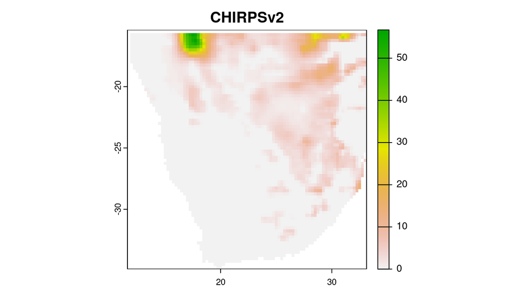

```r
plot(chirps[[1]], main = 'CHIRPSv2')
```

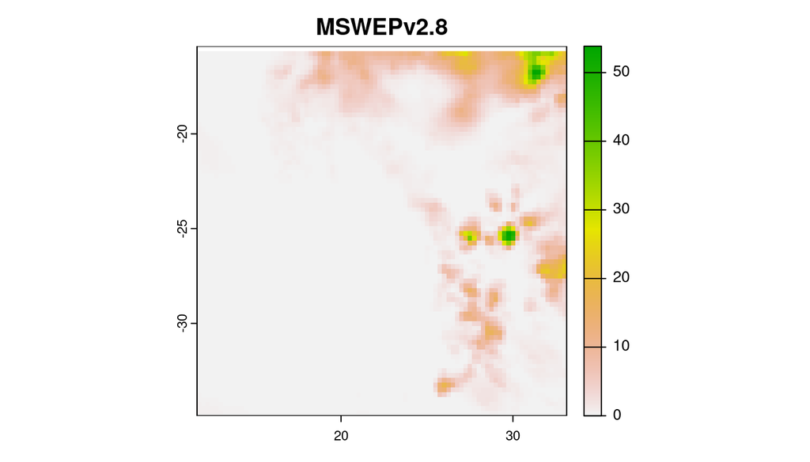

```r
plot(mswep[[1]], main = 'MSWEPv2.8')
```

**Paso 4**: Convertir el archivo de metadatos en un objeto espacial para extraer la información de los productos en función de la ubicación de las estaciones.

```r
head(metadata)
```

```
##            ID LATITUDE LONGITUDE ELEMENT YEAR_START YEAR_END
## 1 BC000068026  -18.367    21.850    PRCP       1932     1992
## 2 BC000068032  -19.983    23.417    PRCP       1921     2022
## 3 BC000068226  -24.017    21.883    PRCP       1958     1992
## 4 BC000068328  -26.050    22.450    PRCP       1939     1992
## 5 BC004612080  -26.467    20.617    PRCP       1960     2022
## 8 BC005847300  -24.667    25.917    PRCP       1925     1997
```

```r
vct <- vect(metadata, geom=c("LONGITUDE", "LATITUDE"))
print(vct)
```

```
##  class       : SpatVector
##  geometry    : points
##  dimensions  : 792, 4  (geometries, attributes)
##  extent      : 15.05, 32.42, -34.833, -17.817  (xmin, xmax, ymin, ymax)
##  coord. ref. :
##  names       :          ID ELEMENT YEAR_START YEAR_END
##  type        :       <chr>   <chr>      <int>    <int>
##  values      : BC000068026    PRCP       1932     1992
##                BC000068032    PRCP       1921     2022
##                BC000068226    PRCP       1958     1992
```

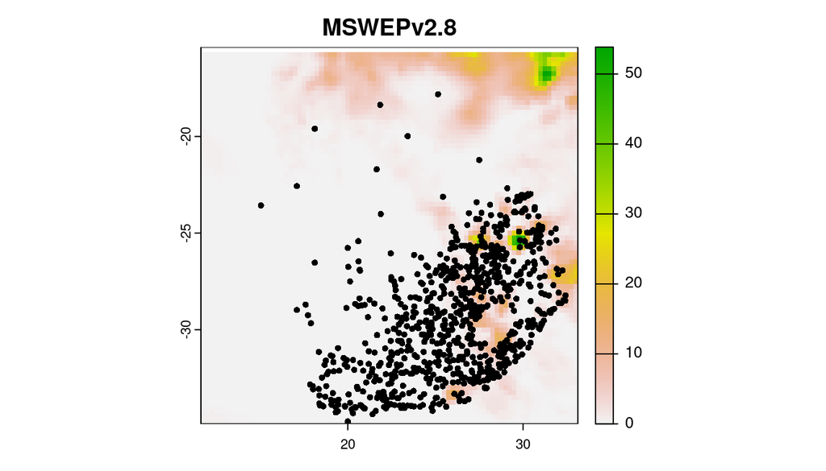

```r
plot(mswep[[1]], main = 'MSWEPv2.8')
points(vct)
```

Podemos usar el paquete **maps** para agregar el contorno de los paises:

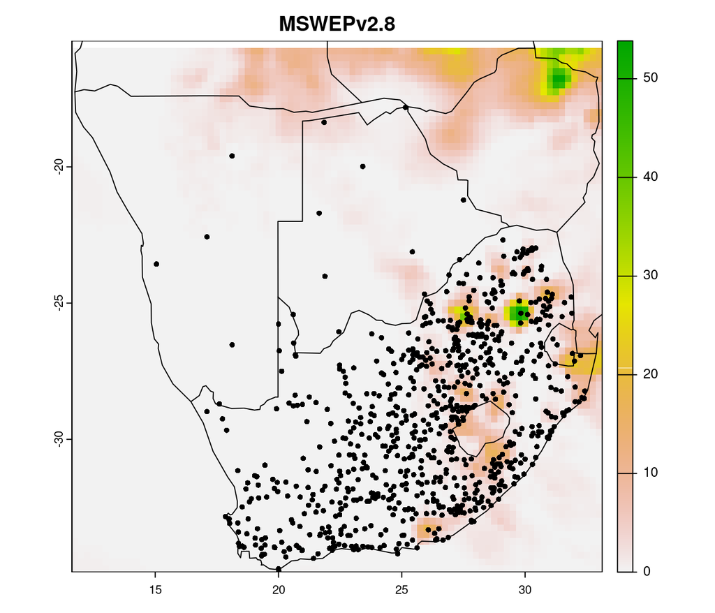

```r
library(maps)
plot(mswep[[1]], main = 'MSWEPv2.8')
points(vct)
map(add = TRUE)
```

**Paso 5**: Extraeremos la información correspondiente a la ubicación de las estaciones utilizando la función **extract** del paquete **terra**. Esta función nos permitirá extraer los valores de los productos de acuerdo a la ubicación de las estaciones espaciales previamente convertidas en un objeto espacial.

```r
chirps_ts <- t(terra::extract(chirps, vct))
mswep_ts <- t(terra::extract(mswep, vct))
dim(chirps_ts)
```

```
## [1] 1097  792
```

```r
dim(mswep_ts)
```

```
## [1] 1097  792
```

```r
chirps_ts[1:5, 1:5]
```

```
##                            [,1]     [,2]         [,3] [,4] [,5]
## ID                    1.0000000 2.000000 3.0000000000    4    5
## chirps_daily_19900101 0.5458916 1.354978 0.0005568612    0    0
## chirps_daily_19900102 0.4041451 0.000000 0.0000000000    0    0
## chirps_daily_19900103 8.3321171 2.423540 0.0000000000    0    0
## chirps_daily_19900104 1.8144772 0.000000 0.0000000000    0    0
```

```r
mswep_ts[1:5, 1:5]
```

```
##                            [,1]        [,2]        [,3]      [,4]       [,5]
## ID                    1.0000000 2.000000000 3.000000000 4.0000000 5.00000000
## MSWEPv280_1990-01-01  3.6173794 0.133561790 0.000000000 0.0000000 0.00000000
## MSWEPv280_1990-01-02  0.4801421 0.008661872 0.001714454 0.0000000 0.00000000
## MSWEPv280_1990-01-03  0.8579947 0.005163515 0.000000000 0.0000000 0.00000000
## MSWEPv280_1990-01-04 29.3101654 0.411440879 0.000000000 0.1994748 0.02766745
```

Removemos la primera fila de resultados en ambos data frames.

```r
chirps_ts <- chirps_ts[-1,]
mswep_ts <- mswep_ts[-1,]
dim(chirps_ts)
```

```
## [1] 1096  792
```

```r
dim(mswep_ts)
```

```
## [1] 1096  792
```

Podemos agregar el nombre de las estaciones a ambos data frames y convertirlos a objetos **zoo**.

```r
colnames(chirps_ts) <- vct$ID
colnames(mswep_ts) <- vct$ID

chirps_ts <- zoo(chirps_ts, index(observations))
mswep_ts <- zoo(mswep_ts, index(observations))
```

Ahora tenemos que agregar las series temporales a escala mensual. Sin embargo, antes de hacerlo, debemos lidiar con los datos faltantes. En el caso del Sur de África, existen varios vacíos en las series temporales para los cuales sí hay datos en los productos de precipitación. Si agregamos los datos sin considerar esto, causaremos un sesgo en la evaluación. Una forma de abordar esta situación y conservar la mayor cantidad de datos es evaluando solo pares de datos, es decir, días en los que haya datos tanto para la estación como para el producto de precipitación.

```r
mask <- abs(observations) / abs(observations)
mask[1:10, 1:5]
```

```
##            BC000068026 BC000068032 BC000068226 BC000068328 BC004612080
## 1990-01-01         NaN         NaN         NaN         NaN         NaN
## 1990-01-02           1         NaN         NaN         NaN         NaN
## 1990-01-03           1         NaN         NaN         NaN         NaN
## 1990-01-04           1         NaN         NaN         NaN         NaN
## 1990-01-05           1         NaN         NaN         NaN         NaN
## 1990-01-06           1           1           1           1         NaN
## 1990-01-07           1         NaN         NaN         NaN         NaN
## 1990-01-08           1           1         NaN         NaN         NaN
## 1990-01-09           1         NaN         NaN           1           1
## 1990-01-10           1           1         NaN         NaN         NaN
```

Ahora multiplicamos estos valores por als series temporales de los productos:

```r
chirps_ts <- chirps_ts * mask
mswep_ts  <- mswep_ts * mask
chirps_ts[1:10, 1:5]
```

```
##            BC000068026 BC000068032 BC000068226 BC000068328 BC004612080
## 1990-01-01         NaN         NaN         NaN         NaN         NaN
## 1990-01-02   0.4041451         NaN         NaN         NaN         NaN
## 1990-01-03   8.3321171         NaN         NaN         NaN         NaN
## 1990-01-04   1.8144772         NaN         NaN         NaN         NaN
## 1990-01-05   5.1150875         NaN         NaN         NaN         NaN
## 1990-01-06   8.4000473    7.642635    0.400118     0.00000         NaN
## 1990-01-07   4.5155077         NaN         NaN         NaN         NaN
## 1990-01-08   9.0528841    9.884509         NaN         NaN         NaN
## 1990-01-09  12.9108858         NaN         NaN     6.37971 0.001561166
## 1990-01-10   5.3035841    2.159117         NaN         NaN         NaN
```

```r
mswep_ts[1:10, 1:5]
```

```
##            BC000068026 BC000068032 BC000068226 BC000068328 BC004612080
## 1990-01-01         NaN         NaN         NaN         NaN         NaN
## 1990-01-02   0.4801421         NaN         NaN         NaN         NaN
## 1990-01-03   0.8579947         NaN         NaN         NaN         NaN
## 1990-01-04  29.3101654         NaN         NaN         NaN         NaN
## 1990-01-05  15.4588585         NaN         NaN         NaN         NaN
## 1990-01-06  47.0791855    2.112805    18.02926    1.942775         NaN
## 1990-01-07  14.0796804         NaN         NaN         NaN         NaN
## 1990-01-08   6.3813167    3.146229         NaN         NaN         NaN
## 1990-01-09  33.4750633         NaN         NaN    1.409944   0.4759395
## 1990-01-10   5.8150024    5.594441         NaN         NaN         NaN
```

Finalmente podemos agregar las series temporales a escala mensual:

```r
observations <- daily2monthly(observations, FUN = sum, na.rm = TRUE)
chirps_ts    <- daily2monthly(chirps_ts, FUN = sum, na.rm = TRUE)
mswep_ts     <- daily2monthly(mswep_ts, FUN = sum, na.rm = TRUE)
```

Podemos graficar una estación:

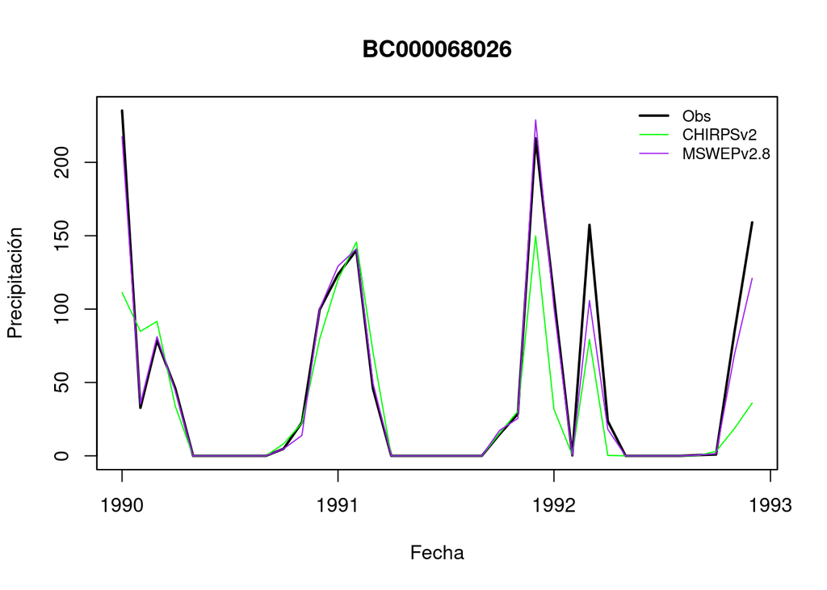

```r
plot(observations[,1], lwd = 2, main = names(observations)[1],
     xlab = 'Fecha', ylab = 'Precipitación')
lines(chirps_ts[,1], col = 'green')
lines(mswep_ts[,1], col = 'purple')
legend('topright', c('Obs', 'CHIRPSv2', 'MSWEPv2.8'), cex = 0.8,
       col = c('black', 'green', 'purple'), lty = 1, lwd = c(2, 1, 1), bty = 'n')
```

Comparemos el orden de las estaciones entre metadatos y observaciones:

```r
all(metadata$ID == names(observations))
```

```
## [1] TRUE
```

Para evaluar el desempeño de las estaciones usaremos la función KGE del paquete hydroGOF, como se muestra en el siguiente ejemplo:

```r
KGE(sim = chirps_ts[,1], obs = observations[,1], method = '2012')
```

```
## [1] 0.6593252
```

```r
KGE(sim = chirps_ts[,1], obs = observations[,1], method = '2012', out.type = 'full')
```

```
## $KGE.value
## [1] 0.6593252
##
## $KGE.elements
##         r      Beta     Gamma
## 0.8423835 0.6985138 0.9820446
```

**Paso 5**: En seguida, debemos de desarrollar un loop para evaluar cada uno de los productos con el KGE y sus componentes:

> - El ciclo tiene que iterar el numero total de estaciones analizadas
> - Debe de guardar el valor del KGE’ y sus componentes.

```r
# Vectores vacios para almacenar los resultados
kges_chirps <- r_chirps <- beta_chirps <- gamma_chirps <- c()

for(i in 1:ncol(chirps_ts)){

  # Extraer los valores del producto y observados
  x <- observations[,i]
  y <- chirps_ts[,i]

  # Calcular el KGE' y sus componentes
  kge_all <- hydroGOF::KGE(sim = y, obs = x, method = "2012", out.type = "full")

  kges_chirps[i]     <- kge_all$KGE.value
  r_chirps[i]        <- kge_all$KGE.elements[1]
  beta_chirps[i]     <- kge_all$KGE.elements[2]
  gamma_chirps[i]    <- kge_all$KGE.elements[3]

}

# Generar un data frame con los resultados
  res_chirps <- data.frame(ID = names(observations), long = metadata$LONGITUDE, lat = metadata$LATITUDE,
                    KGE = kges_chirps, r = r_chirps, beta = beta_chirps, gamma = gamma_chirps)
```

Podemos visualizar los primeros 10 elementos de los resultados:

```r
head(res_chirps, 10)
```

```
##             ID   long     lat       KGE         r      beta     gamma
## 1  BC000068026 21.850 -18.367 0.6593252 0.8423835 0.6985138 0.9820446
## 2  BC000068032 23.417 -19.983 0.6058426 0.9575517 0.6127122 1.0597192
## 3  BC000068226 21.883 -24.017 0.4570457 0.8929958 0.5041185 1.1935228
## 4  BC000068328 22.450 -26.050 0.5784123 0.9822298 0.5797498 0.9715363
## 5  BC004612080 20.617 -26.467 0.4649248 0.8057950 0.5154293 1.1173927
## 6  BC005847300 25.917 -24.667 0.5621092 0.9198873 0.5757213 1.0729242
## 7  BC007137570 25.430 -23.120 0.4069480 0.9126417 0.4467562 1.1949370
## 8  BC008382520 21.650 -21.700 0.6396717 0.9667827 0.6549721 1.0984318
## 9  BC008948490 27.500 -21.217 0.6247496 0.9106075 0.6404717 0.9403236
## 10 BC012192590 25.150 -17.817 0.6053421 0.9730738 0.6062644 0.9985454
```

Ahora realizamos lo mismo para MSWEPv2.8.

```r
# Vectores vacios para almacenar los resultados
kges_mswep <- r_mswep <- beta_mswep <- gamma_mswep <- c()

for(i in 1:ncol(mswep_ts)){

  # Extraer los valores del producto y observados
  x <- observations[,i]
  y <- mswep_ts[,i]

  # Calcular el KGE' y sus componentes
  kge_all <- hydroGOF::KGE(sim = y, obs = x, method = "2012", out.type = "full")

  kges_mswep[i]     <- kge_all$KGE.value
  r_mswep[i]        <- kge_all$KGE.elements[1]
  beta_mswep[i]     <- kge_all$KGE.elements[2]
  gamma_mswep[i]    <- kge_all$KGE.elements[3]

}

# Generar un data frame con los resultados
  res_mswep <- data.frame(ID = names(observations), long = metadata$LONGITUDE, lat = metadata$LATITUDE,
                    KGE = kges_mswep, r = r_mswep, beta = beta_mswep, gamma = gamma_mswep)
```

Podemos visualizar los primeros 10 elementos de los resultados:

```r
head(res_mswep, warning=FALSE, 10)
```

```
##             ID   long     lat       KGE         r      beta     gamma
## 1  BC000068026 21.850 -18.367 0.9252544 0.9860393 0.9276302 1.0124345
## 2  BC000068032 23.417 -19.983 0.5989552 0.8907561 0.6288748 1.1056824
## 3  BC000068226 21.883 -24.017 0.8633348 0.9784374 0.8701128 1.0366298
## 4  BC000068328 22.450 -26.050 0.8379569 0.9853505 0.8673199 1.0918659
## 5  BC004612080 20.617 -26.467 0.7725206 0.9353796 0.7855346 1.0396948
## 6  BC005847300 25.917 -24.667 0.8553874 0.9650888 0.8603185 1.0135306
## 7  BC007137570 25.430 -23.120 0.7248294 0.9944593 0.7271837 1.0354889
## 8  BC008382520 21.650 -21.700 0.4809343 0.9444512 0.5787954 1.2982118
## 9  BC008948490 27.500 -21.217 0.8861970 0.9987780 0.8863450 0.9943279
## 10 BC012192590 25.150 -17.817 0.8789753 0.9916478 0.8847773 1.0360687
```

Finalmente podemos comparar el KGE’ y sus componentes:

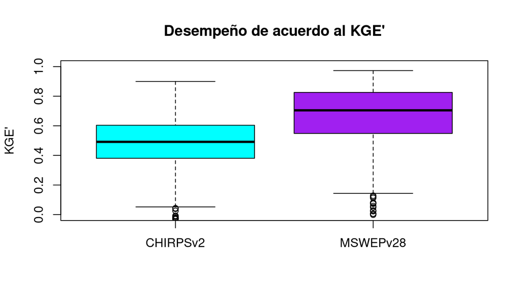

```r
kges <- data.frame(CHIRPSv2 = res_chirps$KGE, MSWEPv28 = res_mswep$KGE)
boxplot(kges, ylim = c(0, 1),
        main = "Desempeño de acuerdo al KGE'", col = c('cyan', 'purple'), ylab = "KGE'")
```

[figure not shown]

```r
r <- data.frame(CHIRPSv2 = res_chirps$r, MSWEPv28 = res_mswep$r)
boxplot(kges, ylim = c(0, 1),
        main = "Desempeño de acuerdo al r", col = c('cyan', 'purple'), ylab = "r")
```

[figure not shown]

```r
beta <- data.frame(CHIRPSv2 = res_chirps$beta, MSWEPv28 = res_mswep$beta)
boxplot(kges, ylim = c(-1, 1),
        main = "Desempeño de acuerdo al Beta", col = c('cyan', 'purple'), ylab = expression(beta))
```

[figure not shown]

```r
gamma <- data.frame(CHIRPSv2 = res_chirps$gamma, MSWEPv28 = res_mswep$gamma)
boxplot(kges, ylim = c(-1, 1),
        main = "Desempeño de acuerdo al Gamma", col = c('cyan', 'purple'), ylab = expression(gamma))
```

### Solucion inciso B

**Paso 1**: Primero cargaremos las series temporales observadas y los metadatos.

```r
observations_path <- 'C:/Users/Data/timeseries_1850-2022.zoo'
metadata_path     <- 'C:/Users/Data/metadata.csv'
```

Después, leeremos los archivos.

```r
observations <- read.zoo(observations_path, header = TRUE)
metadata     <- read.csv(metadata_path)
dim(observations)
```

```
## [1] 62511  1377
```

```r
dim(metadata)
```

```
## [1] 1377    6
```

```r
observations[1:5, 1:5]
```

```
##            BC000068026 BC000068032 BC000068226 BC000068328 BC004612080
## 1850-01-01          NA          NA          NA          NA          NA
## 1850-01-02          NA          NA          NA          NA          NA
## 1850-01-03          NA          NA          NA          NA          NA
## 1850-01-04          NA          NA          NA          NA          NA
## 1850-01-05          NA          NA          NA          NA          NA
```

```r
head(metadata)
```

```
##            ID LATITUDE LONGITUDE ELEMENT YEAR_START YEAR_END
## 1 BC000068026  -18.367    21.850    PRCP       1932     1992
## 2 BC000068032  -19.983    23.417    PRCP       1921     2022
## 3 BC000068226  -24.017    21.883    PRCP       1958     1992
## 4 BC000068328  -26.050    22.450    PRCP       1939     1992
## 5 BC004612080  -26.467    20.617    PRCP       1960     2022
## 6 BC005452830  -25.220    25.670    PRCP       1921     1989
```

Hay que hacer un subset temporal a este objeto para conservar solo el periodo 1990-1992:

```r
observations <- hydroTSM::extract(observations, trgt = 1990:1992)
dim(observations)
```

```
## [1] 1096 1377
```

```r
head(index(observations))
```

```
## [1] "1990-01-01" "1990-01-02" "1990-01-03" "1990-01-04" "1990-01-05"
## [6] "1990-01-06"
```

```r
tail(index(observations))
```

```
## [1] "1992-12-26" "1992-12-27" "1992-12-28" "1992-12-29" "1992-12-30"
## [6] "1992-12-31"
```

Ahora la aplicaremos a cada una de las series temporales (columnas del objeto *zoo*). Recuerda que el 2 significa que aplicaremos la función por columna.

```r
missing_data <- apply(observations, 2, get_ratio_md)
head(missing_data, 6)
```

```
##  BC000068026  BC000068032  BC000068226  BC000068328  BC004612080  BC005452830
## 0.0027372263 0.0000000000 0.0009124088 0.0018248175 0.0000000000 1.0000000000
```

Seleccionemos umbrales de 0.5 (50%), 0.25 (25%), 0.1 (10%), 0.05 (5%), 0.01 (1$) y 0 como límite de datos faltantes.

```r
exclude_pos_50      <- which(missing_data > 0.50)
exclude_pos_25      <- which(missing_data > 0.25)
exclude_pos_10      <- which(missing_data > 0.10)
exclude_pos_05      <- which(missing_data > 0.05)
exclude_pos_01      <- which(missing_data > 0.01)
exclude_pos_00      <- which(missing_data > 0)

length(exclude_pos_50)
```

```
## [1] 515
```

```r
length(exclude_pos_25)
```

```
## [1] 576
```

```r
length(exclude_pos_10)
```

```
## [1] 618
```

```r
length(exclude_pos_05)
```

```
## [1] 661
```

```r
length(exclude_pos_01)
```

```
## [1] 752
```

```r
length(exclude_pos_00)
```

```
## [1] 819
```

Excluir estaciones respectivas:

```r
metadata_50     <- metadata[-exclude_pos_50,]
metadata_25     <- metadata[-exclude_pos_25,]
metadata_10     <- metadata[-exclude_pos_10,]
metadata_05     <- metadata[-exclude_pos_05,]
metadata_01     <- metadata[-exclude_pos_01,]
metadata_00     <- metadata[-exclude_pos_00,]
```

Ahora convertiremos los metadatos en objetos espaciales:

```r
vct    <- vect(metadata, geom=c("LONGITUDE", "LATITUDE"))
vct_50 <- vect(metadata_50, geom=c("LONGITUDE", "LATITUDE"))
vct_25 <- vect(metadata_25, geom=c("LONGITUDE", "LATITUDE"))
vct_10 <- vect(metadata_10, geom=c("LONGITUDE", "LATITUDE"))
vct_05 <- vect(metadata_05, geom=c("LONGITUDE", "LATITUDE"))
vct_01 <- vect(metadata_01, geom=c("LONGITUDE", "LATITUDE"))
vct_00 <- vect(metadata_00, geom=c("LONGITUDE", "LATITUDE"))
```

Ahora realizaremos las figuras usando la primera capa de MSWEPv2.8:

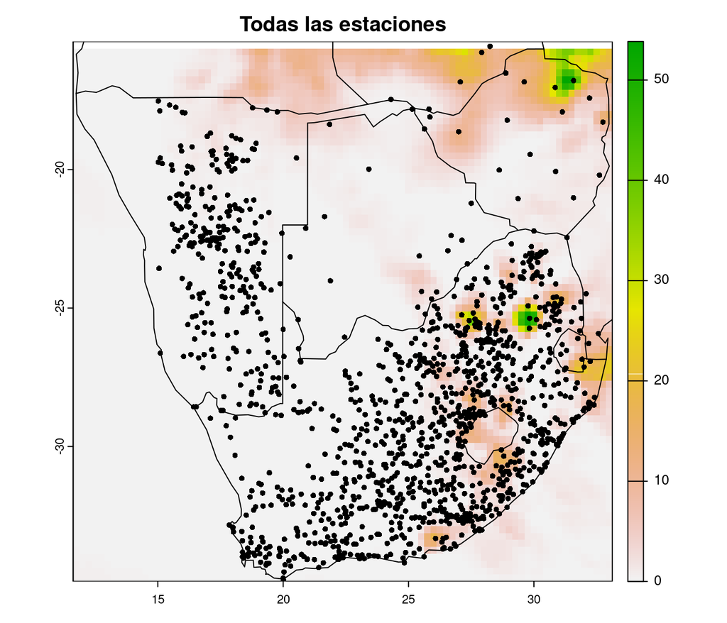

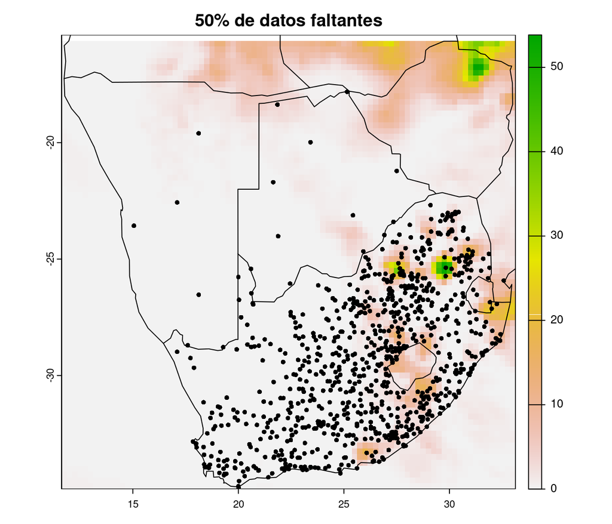

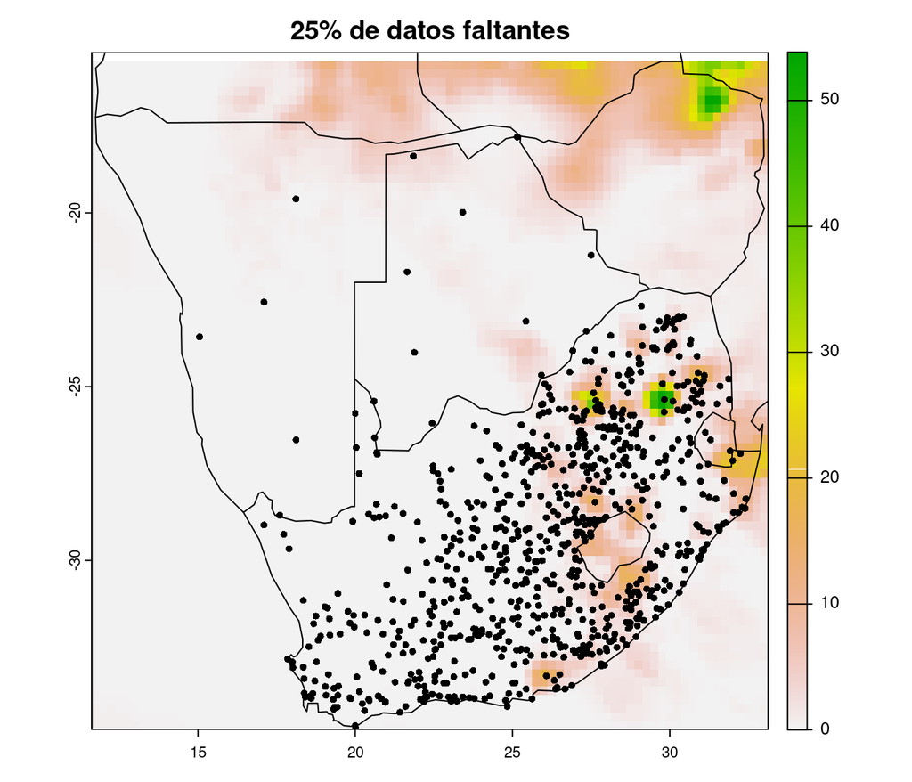

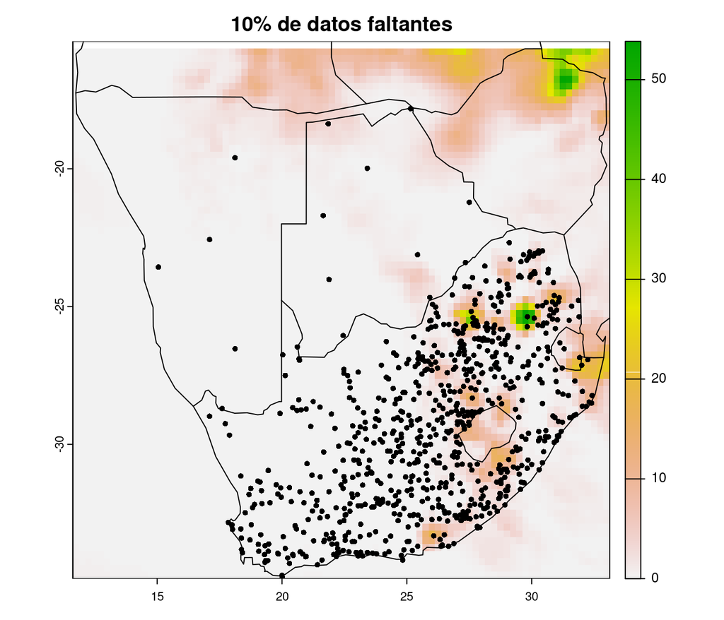

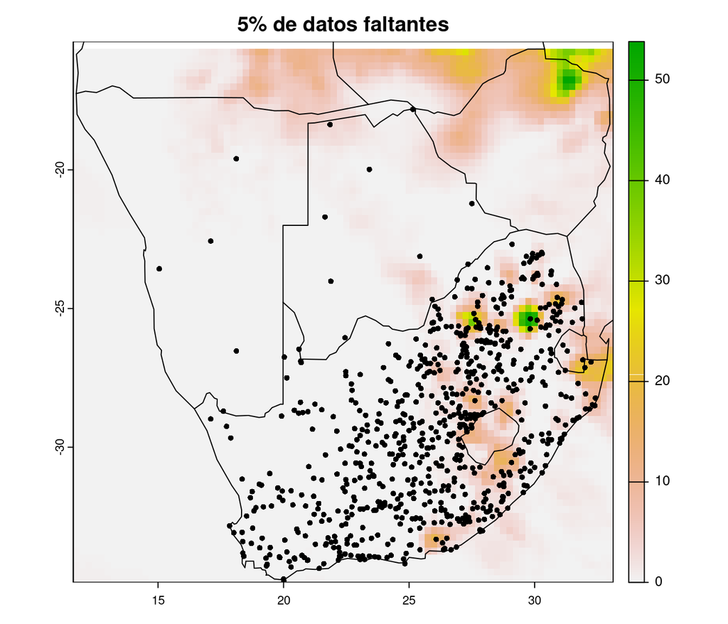

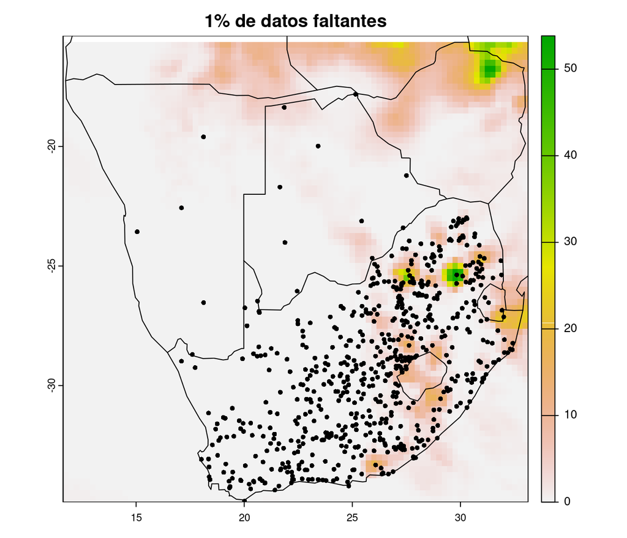

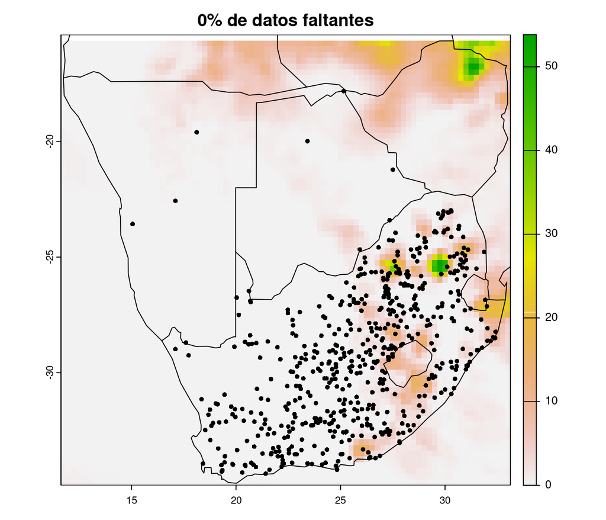